# Heart disease prediction

```python
# import the basic packages
import numpy as np
import pandas as pd
import matplotlib.pyplot as plt
from matplotlib import rcParams

%matplotlib inline
from sklearn.preprocessing import LabelEncoder
import warnings
warnings.filterwarnings('ignore')
```

## Read Data

```python
data = pd.read_csv('Heart.csv')
data.head()
```

|  | patient_id | slope_of_peak_exercise_st_segment | thal | resting_blood_pressure | chest_pain_type | num_major_vessels | fasting_blood_sugar_gt_120_mg_per_dl | resting_ekg_results | serum_cholesterol_mg_per_dl | oldpeak_eq_st_depression | sex | age | max_heart_rate_achieved | exercise_induced_angina | heart_disease_present |
| --- | --- | --- | --- | --- | --- | --- | --- | --- | --- | --- | --- | --- | --- | --- | --- |
| 0 | 0z64un | 1 | normal | 128 | 2 | 0 | 0 | 2 | 308 | 0.0 | 1 | 45 | 170 | 0 | 0 |
| 1 | ryoo3j | 2 | normal | 110 | 3 | 0 | 0 | 0 | 214 | 1.6 | 0 | 54 | 158 | 0 | 0 |
| 2 | yt1s1x | 1 | normal | 125 | 4 | 3 | 0 | 2 | 304 | 0.0 | 1 | 77 | 162 | 1 | 1 |
| 3 | l2xjde | 1 | reversible_defect | 152 | 4 | 0 | 0 | 0 | 223 | 0.0 | 1 | 40 | 181 | 0 | 1 |
| 4 | oyt4ek | 3 | reversible_defect | 178 | 1 | 0 | 0 | 2 | 270 | 4.2 | 1 | 59 | 145 | 0 | 0 |

## Basic checks and EDA

```python
data.info()#To print a concise summary of a DataFrame
data.describe() # distribution of the features in the dataset
```

```
<class 'pandas.core.frame.DataFrame'>
RangeIndex: 180 entries, 0 to 179
Data columns (total 15 columns):
 #   Column                                Non-Null Count  Dtype
---  ------                                --------------  -----
 0   patient_id                            180 non-null    object
 1   slope_of_peak_exercise_st_segment     180 non-null    int64
 2   thal                                  180 non-null    object
 3   resting_blood_pressure                180 non-null    int64
 4   chest_pain_type                       180 non-null    int64
 5   num_major_vessels                     180 non-null    int64
 6   fasting_blood_sugar_gt_120_mg_per_dl  180 non-null    int64
 7   resting_ekg_results                   180 non-null    int64
 8   serum_cholesterol_mg_per_dl           180 non-null    int64
 9   oldpeak_eq_st_depression              180 non-null    float64
 10  sex                                   180 non-null    int64
 11  age                                   180 non-null    int64
 12  max_heart_rate_achieved               180 non-null    int64
 13  exercise_induced_angina               180 non-null    int64
 14  heart_disease_present                 180 non-null    int64
dtypes: float64(1), int64(12), object(2)
memory usage: 21.2+ KB
```

|  | slope_of_peak_exercise_st_segment | resting_blood_pressure | chest_pain_type | num_major_vessels | fasting_blood_sugar_gt_120_mg_per_dl | resting_ekg_results | serum_cholesterol_mg_per_dl | oldpeak_eq_st_depression | sex | age | max_heart_rate_achieved | exercise_induced_angina | heart_disease_present |
| --- | --- | --- | --- | --- | --- | --- | --- | --- | --- | --- | --- | --- | --- |
| count | 180.000000 | 180.000000 | 180.000000 | 180.000000 | 180.000000 | 180.000000 | 180.000000 | 180.000000 | 180.000000 | 180.000000 | 180.000000 | 180.000000 | 180.000000 |
| mean | 1.550000 | 131.311111 | 3.155556 | 0.694444 | 0.161111 | 1.050000 | 249.211111 | 1.010000 | 0.688889 | 54.811111 | 149.483333 | 0.316667 | 0.444444 |
| std | 0.618838 | 17.010443 | 0.938454 | 0.969347 | 0.368659 | 0.998742 | 52.717969 | 1.121357 | 0.464239 | 9.334737 | 22.063513 | 0.466474 | 0.498290 |
| min | 1.000000 | 94.000000 | 1.000000 | 0.000000 | 0.000000 | 0.000000 | 126.000000 | 0.000000 | 0.000000 | 29.000000 | 96.000000 | 0.000000 | 0.000000 |
| 25% | 1.000000 | 120.000000 | 3.000000 | 0.000000 | 0.000000 | 0.000000 | 213.750000 | 0.000000 | 0.000000 | 48.000000 | 132.000000 | 0.000000 | 0.000000 |
| 50% | 1.000000 | 130.000000 | 3.000000 | 0.000000 | 0.000000 | 2.000000 | 245.500000 | 0.800000 | 1.000000 | 55.000000 | 152.000000 | 0.000000 | 0.000000 |
| 75% | 2.000000 | 140.000000 | 4.000000 | 1.000000 | 0.000000 | 2.000000 | 281.250000 | 1.600000 | 1.000000 | 62.000000 | 166.250000 | 1.000000 | 1.000000 |
| max | 3.000000 | 180.000000 | 4.000000 | 3.000000 | 1.000000 | 2.000000 | 564.000000 | 6.200000 | 1.000000 | 77.000000 | 202.000000 | 1.000000 | 1.000000 |

```python
data.shape
```

```
(180, 15)
```

```python
data['heart_disease_present'].value_counts()
```

```
0    100
1     80
Name: heart_disease_present, dtype: int64
```

```python
data.isnull().sum()
```

```
patient_id                              0
slope_of_peak_exercise_st_segment       0
thal                                    0
resting_blood_pressure                  0
chest_pain_type                         0
num_major_vessels                       0
fasting_blood_sugar_gt_120_mg_per_dl    0
resting_ekg_results                     0
serum_cholesterol_mg_per_dl             0
oldpeak_eq_st_depression                0
sex                                     0
age                                     0
max_heart_rate_achieved                 0
exercise_induced_angina                 0
heart_disease_present                   0
dtype: int64
```

```python
import seaborn as sns
from matplotlib import pyplot as plt
```

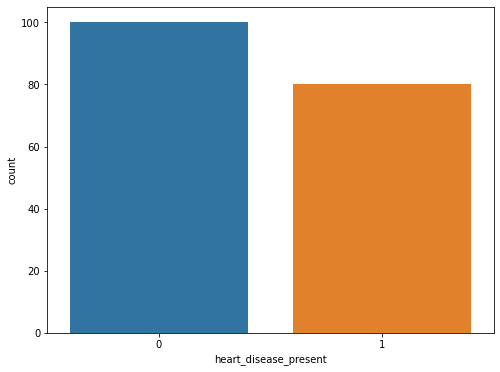

```python
# check the target = 'heart_disease_present' distribution

plt.rcParams['figure.figsize'] = (8, 6)

sns.countplot(x='heart_disease_present', data=data);
```

##### Let's see how much males and females are there in the dataset who have a heart problem

```python
data.groupby(by=['sex', 'heart_disease_present'])['heart_disease_present'].count()
```

```
sex  heart_disease_present
0    0                        45
     1                        11
1    0                        55
     1                        69
Name: heart_disease_present, dtype: int64
```

```python
pd.crosstab(data['sex'], data['heart_disease_present'])
```

| heart_disease_present sex | 0 | 1 |
| --- | --- | --- |
| 0 | 45 | 11 |
| 1 | 55 | 69 |

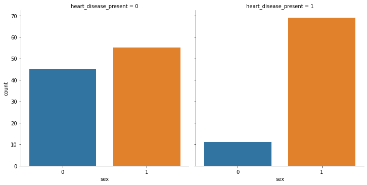

```python
sns.catplot(x='sex', col='heart_disease_present', kind='count', data=data);
```

```python
print("% of women suffering from heart disease: " , data.loc[data.sex == 0].heart_disease_present.sum()/data.loc[data.sex == 0].heart_disease_present.count())
print("% of men suffering from heart disease:   " , data.loc[data.sex == 1].heart_disease_present.sum()/data.loc[data.sex == 1].heart_disease_present.count())
```

```
% of women suffering from heart disease:  0.19642857142857142
% of men suffering from heart disease:    0.5564516129032258
```

##### Percentage of Males is more in this dataset who have a heart disease.

```python
data.groupby(by=['chest_pain_type', 'heart_disease_present'])['heart_disease_present'].count()
```

```
chest_pain_type  heart_disease_present
1                0                         9
                 1                         4
2                0                        24
                 1                         4
3                0                        44
                 1                        13
4                0                        23
                 1                        59
Name: heart_disease_present, dtype: int64
```

```python
pd.crosstab(data['chest_pain_type'], data['heart_disease_present']).style.background_gradient(cmap='autumn_r')
```

| heart_disease_present chest_pain_type | 0 | 1 |
| --- | --- | --- |
| 1 | 9 | 4 |
| 2 | 24 | 4 |
| 3 | 44 | 13 |
| 4 | 23 | 59 |

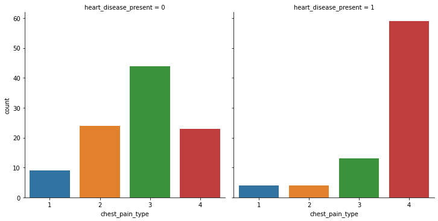

```python
sns.catplot(x='chest_pain_type', col='heart_disease_present', kind='count', data=data);
```

#### Patients who had chest pain type 4 is more in the category of people with disease. Also, chest pain type 3 is not that serious as there are many people (~45) who had chest pain type 3 without heart disease.

##### Let's see the fbs feature now, fasting blood sugar (1 = true; 0 = false)

```python
data.groupby(by=['fasting_blood_sugar_gt_120_mg_per_dl', 'heart_disease_present'])['heart_disease_present'].count()
```

```
fasting_blood_sugar_gt_120_mg_per_dl  heart_disease_present
0                                     0                        84
                                      1                        67
1                                     0                        16
                                      1                        13
Name: heart_disease_present, dtype: int64
```

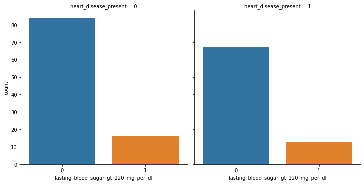

```python
sns.catplot(x='fasting_blood_sugar_gt_120_mg_per_dl', col='heart_disease_present', kind='count', data=data);
```

```python
data.groupby(by=['thal', 'heart_disease_present'])['heart_disease_present'].count()
```

```
thal               heart_disease_present
fixed_defect       0                         4
                   1                         4
normal             0                        78
                   1                        20
reversible_defect  0                        18
                   1                        56
Name: heart_disease_present, dtype: int64
```

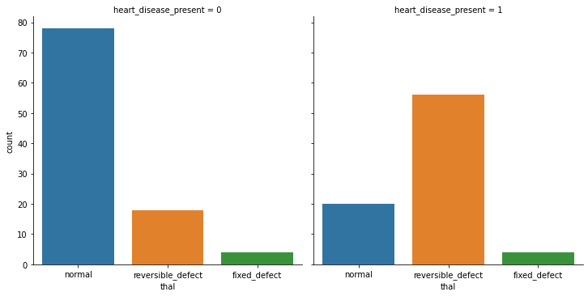

```python
sns.catplot(x='thal', col='heart_disease_present', kind='count', data=data);
```

#### Most of the people with heart disease have thal as reversible defect.. Interesting.

#### Let's check the exang feature

#### exercise induced angina (1 = yes; 0 = no)

```python
data.groupby(by=['exercise_induced_angina', 'heart_disease_present'])['heart_disease_present'].count()
```

```
exercise_induced_angina  heart_disease_present
0                        0                        87
                         1                        36
1                        0                        13
                         1                        44
Name: heart_disease_present, dtype: int64
```

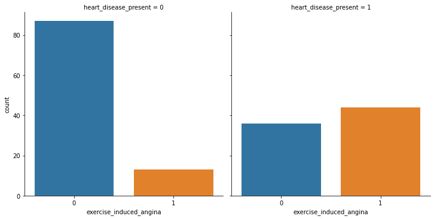

```python
sns.catplot(x='exercise_induced_angina', col='heart_disease_present', kind='count', data=data);
```

#### People with exercise induced angina is more in the category with disease.

#### Let's go for scatter matrix for the continous variables, rather than plotting each pair

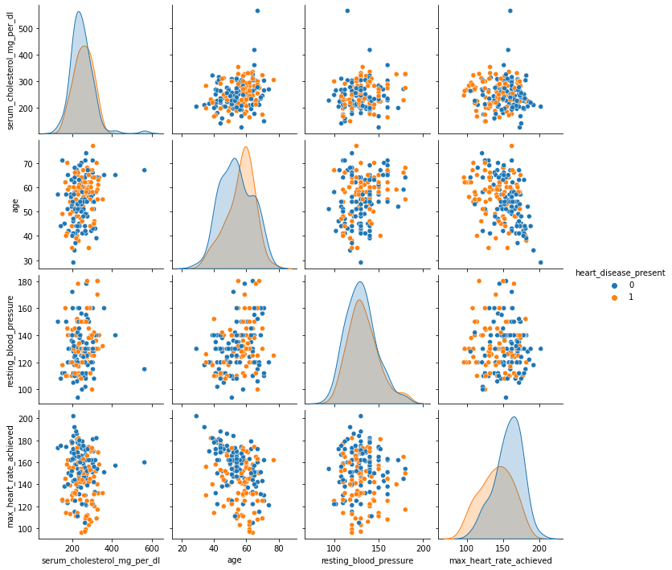

```python
sns.pairplot(data[['serum_cholesterol_mg_per_dl', 'age', 'resting_blood_pressure', 'max_heart_rate_achieved', 'heart_disease_present']], hue='heart_disease_present');
```

#### There is no notable relationship among the features that we can find from the scatter. Let's check the corrleation among these features.

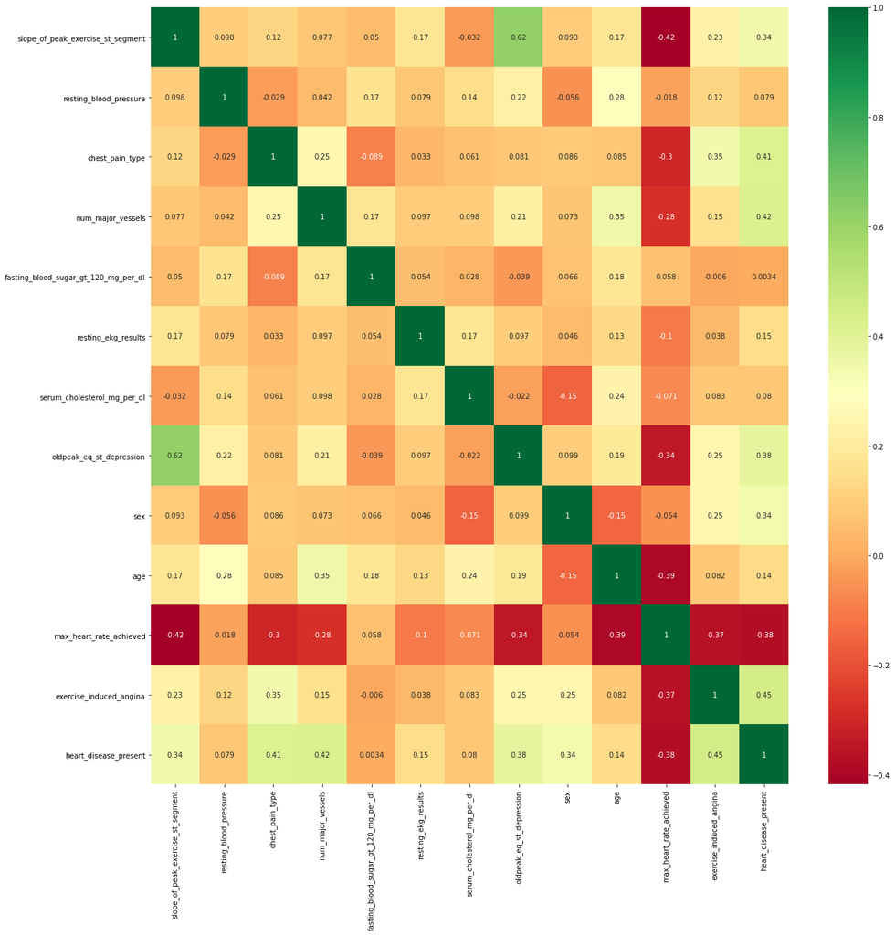

```python
import seaborn as sns
#get correlations of each features in dataset
corrmat = data.corr()
top_corr_features = corrmat.index
plt.figure(figsize=(20,20))
#plot heat map
g=sns.heatmap(data[top_corr_features].corr(),annot=True,cmap="RdYlGn")
```

##### This the end of basic EDA on Heart Disease Dataset.

```python
X = data.iloc[:,1:-1]
y = data.heart_disease_present
```

```python
enc = LabelEncoder()
X.thal = enc.fit_transform(X.thal)
```

## Training data

```python
from sklearn.model_selection import train_test_split
X_train,X_test,y_train,y_test = train_test_split(X,y,test_size=0.2,random_state=10)
```

```python
from sklearn.preprocessing import StandardScaler
sc = StandardScaler()
X_train = sc.fit_transform(X_train)
X_test = sc.transform(X_test)
```

## Model 1: Logistic Regression

```python
from sklearn.linear_model import LogisticRegression
from sklearn.metrics import accuracy_score,confusion_matrix,classification_report
alpha = [10**x for x in range(-4,4,1)]
acc = []
for c in alpha:
    classifier = LogisticRegression(penalty='l2',tol=0.0001,C=c,max_iter=1000)
    classifier.fit(X_train,y_train)
    y_predict = classifier.predict(X_test)
    accuracy = accuracy_score(y_predict,y_test)
    acc.append(accuracy)
    print(accuracy)
    print(c)
```

```
0.6111111111111112
0.0001
0.7777777777777778
0.001
0.8611111111111112
0.01
0.8333333333333334
0.1
0.8055555555555556
1
0.8055555555555556
10
0.8055555555555556
100
0.8055555555555556
1000
```

```python
classifier = LogisticRegression(penalty='l2',tol=0.0001,C=0.01,max_iter=1000)
classifier.fit(X_train,y_train)
y_pred= classifier.predict(X_test)
print(classification_report(y_test, y_predict))
```

```
              precision    recall  f1-score   support

           0       0.86      0.82      0.84        22
           1       0.73      0.79      0.76        14

    accuracy                           0.81        36
   macro avg       0.80      0.80      0.80        36
weighted avg       0.81      0.81      0.81        36
```

```python
y_pred_train = classifier.predict(X_train)
cf_test = confusion_matrix(y_pred, y_test)
cf_train = confusion_matrix(y_pred_train, y_train)
cf_train
```

```
array([[73, 17],
       [ 5, 49]], dtype=int64)
```

```python
print('Accuracy for training set for Logistic Regression = {}'.format((cf_train[0][0] + cf_train[1][1])/len(y_train)))
print('Accuracy for test set for Logistic Regression = {}'.format((cf_test[0][0] + cf_test[1][1])/len(y_test)))
```

```
Accuracy for training set for Logistic Regression = 0.8472222222222222
Accuracy for test set for Logistic Regression = 0.8611111111111112
```

# Model 2: XGBoost

```python
print(f"Best paramters: {best_params}")
```

[output not shown]

```python
rf = XGBClassifier(
 learning_rate =0.01,
 n_estimators=5000,
 max_depth=4,
 min_child_weight=6,
 gamma=0,
 subsample=0.8,
 colsample_bytree=0.8,
 reg_alpha=0.005,
 objective= 'binary:logistic',
 nthread=4,
 scale_pos_weight=1,
 seed=27)
rf.fit(X_train, y_train)
```

[output not shown]

```python
y_pred=rf.predict(X_test)
y_pred_train=rf.predict(X_train)
```

[output not shown]

```python
cf_test = confusion_matrix(y_pred, y_test)
cf_train = confusion_matrix(y_pred_train, y_train)
cf_train
```

[output not shown]

```python
print('Accuracy for training set for Xgboost = {}'.format((cf_train[0][0] + cf_train[1][1])/len(y_train)))
print('Accuracy for test set for Xgboost = {}'.format((cf_test[0][0] + cf_test[1][1])/len(y_test)))
```

[output not shown]

# Model 3: SVM

```python
from sklearn.model_selection import GridSearchCV
from sklearn.svm import SVC
# defining parameter range
param_grid = {'C': [0.1,1.0, 1, 10,42],
              'gamma': [1,0.1,'scale','auto'],
              'kernel': ['rbf','linear','sigmoid','poly']}

grid = GridSearchCV(SVC(), param_grid, refit = True, verbose = 3)

# fitting the model for grid search
grid.fit(X_train, y_train)
#grid_predictions = grid.predict(X_test)
# print best parameter after tuning
```

[output not shown]

[output not shown]

[output not shown]

[output cut: 705 more lines]

[output not shown]

```
[Parallel(n_jobs=1)]: Done 400 out of 400 | elapsed:    3.5s finished
```

```
GridSearchCV(estimator=SVC(),
             param_grid={'C': [0.1, 1.0, 1, 10, 42],
                         'gamma': [1, 0.1, 'scale', 'auto'],
                         'kernel': ['rbf', 'linear', 'sigmoid', 'poly']},
             verbose=3)
```

```python
print(grid.best_params_)

# print how our model looks after hyper-parameter tuning
print(grid.best_estimator_)
```

```
{'C': 0.1, 'gamma': 'scale', 'kernel': 'sigmoid'}
SVC(C=0.1, kernel='sigmoid')
```

```python
from sklearn.svm import SVC
classifier = SVC(kernel = 'rbf',C=0.1,gamma='scale')
classifier.fit(X_train, y_train)
y_pred = classifier.predict(X_test)
print(classification_report(y_test, y_predict))
```

```
              precision    recall  f1-score   support

           0       0.86      0.82      0.84        22
           1       0.73      0.79      0.76        14

    accuracy                           0.81        36
   macro avg       0.80      0.80      0.80        36
weighted avg       0.81      0.81      0.81        36
```

```python
y_pred_train = classifier.predict(X_train)
cf_test = confusion_matrix(y_pred, y_test)
cf_train = confusion_matrix(y_pred_train, y_train)
cf_train
```

```
array([[76, 20],
       [ 2, 46]], dtype=int64)
```

```python
print('Accuracy for training set for SVM = {}'.format((cf_train[0][0] + cf_train[1][1])/len(y_train)))
print('Accuracy for test set for SVM = {}'.format((cf_test[0][0] + cf_test[1][1])/len(y_test)))
```

```
Accuracy for training set for SVM = 0.8472222222222222
Accuracy for test set for SVM = 0.8611111111111112
```

# Model 4: DecisionTreeClassifier

```python
from sklearn.model_selection import GridSearchCV
from sklearn import tree
from sklearn.tree import DecisionTreeClassifier
param_dist = {
    "max_features": ['auto', 'sqrt', 'log2'],
    "criterion":["gini","entropy"],
    "max_depth":[1,2,3,4,5,6,7,8,9,10,None]
}

grid = GridSearchCV(DecisionTreeClassifier(random_state = 10), param_grid = param_dist, cv=60, n_jobs=-2,)
grid.fit(X_train, y_train)
print (grid.best_estimator_)
print (grid.best_score_)
print (grid.best_params_)
```

```
DecisionTreeClassifier(max_depth=3, max_features='auto', random_state=10)
0.7861111111111111
{'criterion': 'gini', 'max_depth': 3, 'max_features': 'auto'}
```

```python
from sklearn.metrics import accuracy_score,confusion_matrix
model = DecisionTreeClassifier(criterion='gini', max_depth=3, max_features='auto',random_state = 10)
model.fit(X_train,y_train)
y_pred = model.predict(X_test)
```

```python
y_pred_train = classifier.predict(X_train)
cf_test = confusion_matrix(y_pred, y_test)
cf_train = confusion_matrix(y_pred_train, y_train)
cf_train
```

```
array([[76, 20],
       [ 2, 46]], dtype=int64)
```

```python
print('Accuracy for training set for decisionTree = {}'.format((cf_train[0][0] + cf_train[1][1])/len(y_train)))
print('Accuracy for test set for decisionTree = {}'.format((cf_test[0][0] + cf_test[1][1])/len(y_test)))
```

```
Accuracy for training set for decisionTree = 0.8472222222222222
Accuracy for test set for decisionTree = 0.7777777777777778
```

# Model 5: KNN

```python
from matplotlib import pyplot as plt
from sklearn.neighbors import KNeighborsClassifier
from sklearn.model_selection import cross_val_score
```

```python
knn_scores = []
for k in range(1,7):
    knn_classifier = KNeighborsClassifier(n_neighbors = k)
    score = cross_val_score(knn_classifier,X,y,cv=10)
    knn_scores.append(score.mean())
```

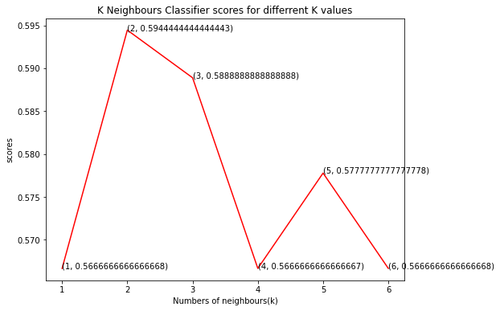

```python
plt.plot([k for k in range(1,7)],knn_scores,color = 'red')
for i in range(1,7):
    plt.text(i,knn_scores[i-1],(i,knn_scores[i-1])) #plt.text(x,y,s),x,y denote position,s denote the text
plt.xticks([i for i in range(1,7)])
plt.xlabel('Numbers of neighbours(k)')
plt.ylabel('scores')
plt.title('K Neighbours Classifier scores for differrent K values')
```

```python
model2 = KNeighborsClassifier(n_neighbors=2,metric='euclidean')
model2.fit(X_train,y_train)
y_predict2 = model2.predict(X_test)
print( accuracy_score(y_test,y_predict2))
print(classification_report(y_test, y_predict2))
```

```
0.8333333333333334
              precision    recall  f1-score   support

           0       0.79      1.00      0.88        22
           1       1.00      0.57      0.73        14

    accuracy                           0.83        36
   macro avg       0.89      0.79      0.80        36
weighted avg       0.87      0.83      0.82        36
```

```python
y_pred_train = classifier.predict(X_train)
cf_test = confusion_matrix(y_predict2, y_test)
cf_train = confusion_matrix(y_pred_train, y_train)
cf_train
```

```
array([[76, 20],
       [ 2, 46]], dtype=int64)
```

```python
print('Accuracy for training set for KNN = {}'.format((cf_train[0][0] + cf_train[1][1])/len(y_train)))
print('Accuracy for test set for KNN = {}'.format((cf_test[0][0] + cf_test[1][1])/len(y_test)))
```

```
Accuracy for training set for KNN = 0.8472222222222222
Accuracy for test set for KNN = 0.8333333333333334
```

# Model 6: Random Forest

```python
from sklearn.metrics import classification_report
from sklearn.ensemble import RandomForestClassifier

model6 = RandomForestClassifier()# get instance of model
model6.fit(X_train, y_train) # Train/Fit model

y_pred6 = model6.predict(X_test) # get y predictions

print(classification_report(y_test, y_pred6)) # output accuracy
```

```
              precision    recall  f1-score   support

           0       0.83      0.91      0.87        22
           1       0.83      0.71      0.77        14

    accuracy                           0.83        36
   macro avg       0.83      0.81      0.82        36
weighted avg       0.83      0.83      0.83        36
```

```python
y_pred6_train = classifier.predict(X_train)
cf_test = confusion_matrix(y_pred6, y_test)
cf_train = confusion_matrix(y_pred6_train, y_train)
cf_train
```

```
array([[76, 20],
       [ 2, 46]], dtype=int64)
```

```python
print('Accuracy for training set for Random Forest = {}'.format((cf_train[0][0] + cf_train[1][1])/len(y_train)))
print('Accuracy for test set for Random Forest = {}'.format((cf_test[0][0] + cf_test[1][1])/len(y_test)))
```

```
Accuracy for training set for Random Forest = 0.8472222222222222
Accuracy for test set for Random Forest = 0.8333333333333334
```

## Conclusion

1.Logistic regression:86%  
2.Support Vector Classifier: 86.1%  
3.Decision Tree Classifier: 77.8%  
4:K Neighbors Classifier: 83%  
5.Random Forest Classifier: 83%